# Reproducible Research: Week 2 Project

James Schneider – schneider.james@gmail.com

## 1. Loading and Preprocessing the Data

Please click on the tabs below to review loading the data set into R, viewing the head and tail of the data frame, libraries used for the code, and a quick summary of the data set using the summary function – summary() – in base R. In addition, the code chunks can be viewed by clicking the `Code` button to the right of each heading. In the upper right of the document, there is a `Code` drop down option to reveal all code chunks.

### Read Data

```r
# Reading Data
activity <- read.csv("activity.csv", header = TRUE, sep = ",", na.strings = "NA")
# Convert Date
activity$date <- as.Date(activity$date, "%Y-%m-%d")
```

```
activity <- read.csv("activity.csv", header = TRUE, sep = ",", na.strings = "NA")
# Convert Date
activity$date <- as.Date(activity$date, "%Y-%m-%d")
```

The following variables are contained within the data set:

- `steps`: Number of steps taking in a 5-minute interval (missing values are coded as NA).
- `date`: The date on which the measurement was taken in YYYY-MM-DD format.
- `interval`: Identifier for the 5-minute interval in which measurement was taken.

### Libraries

Below are the libraries used for the data analysis:

```r
# Loading Libraries
library(knitr)
library(kableExtra)
library(dplyr)
library(ggplot2)

# Library Information Table
lib_tbl <- data.frame(Libraries = c("knitr", "dplyr", "kableExtra", "ggplot2"),
                                      LibraryInformation = c("knitr is used to help weave human-readable documents and tangle machine readable code.",
                                                            "dplyr provides for easy data manipulation on data frames.",
                                                            "kableExtra helps in building tables for HTML or LaTeX by using the kable() from the knitr package.",
                                                            "ggplot2 helps in designing plots, charts, and graphs"))

# Using kableExtra to Build Library Table
kable(lib_tbl, col.names = c("Library", "Library Details"), caption = "Libraries used in the data analysis") %>%
  kable_styling(full_width = FALSE, font_size = 14) %>%
  column_spec(1, bold = T, border_right = T, background = "#F9D5D4", color = "darkslategray") %>%
  column_spec(2, width = "30em", background = "white") %>%
  row_spec(0, background = "#EA6864", color = "white")
```

Libraries used in the data analysis

| Library | Library Details |
| --- | --- |
| knitr | knitr is used to help weave human-readable documents and tangle machine readable code. |
| dplyr | dplyr provides for easy data manipulation on data frames. |
| kableExtra | kableExtra helps in building tables for HTML or LaTeX by using the kable() from the knitr package. |
| ggplot2 | ggplot2 helps in designing plots, charts, and graphs |

### Head: activity

```r
# Buliding Table
kable(head(activity, 10), align = c("l", "l", "c"), col.names = c("Steps", "Date", "Interval"), row.names = TRUE, caption = "First 10 columns from the activity data frame") %>%
  kable_styling(bootstrap_options = "condensed", full_width = FALSE, font_size = 14) %>%
  row_spec(row = 0, background = "#EA6864", color = "white", hline_after = TRUE) %>%
  column_spec(c(1:3), width = "10em") %>%
  column_spec(2, border_left = TRUE) %>%
  column_spec(1, background = "#F9D5D4", color = "darkslategray", width = "4em")
```

|  | Steps | Date | Interval |
| --- | --- | --- | --- |
| 1 | NA | 2012-10-01 | 0 |
| 2 | NA | 2012-10-01 | 5 |
| 3 | NA | 2012-10-01 | 10 |
| 4 | NA | 2012-10-01 | 15 |
| 5 | NA | 2012-10-01 | 20 |
| 6 | NA | 2012-10-01 | 25 |
| 7 | NA | 2012-10-01 | 30 |
| 8 | NA | 2012-10-01 | 35 |
| 9 | NA | 2012-10-01 | 40 |
| 10 | NA | 2012-10-01 | 45 |

### Tail: activity

```r
kable(tail(activity, 10), align = c("l", "l", "c"), col.names = c("Steps", "Date", "Interval"), row.names = TRUE, caption = "Last 10 columns from the activity data frame") %>%
  kable_styling(bootstrap_options = "condensed", full_width = FALSE, font_size = 14) %>%
  row_spec(row = 0, background = "#EA6864", color = "white") %>%
  column_spec(c(1:3), width = "10em") %>%
  column_spec(2, border_left = TRUE) %>%
  column_spec(1, background = "#F9D5D4", color = "darkslategray", width = "4em")
```

|  | Steps | Date | Interval |
| --- | --- | --- | --- |
| 17559 | NA | 2012-11-30 | 2310 |
| 17560 | NA | 2012-11-30 | 2315 |
| 17561 | NA | 2012-11-30 | 2320 |
| 17562 | NA | 2012-11-30 | 2325 |
| 17563 | NA | 2012-11-30 | 2330 |
| 17564 | NA | 2012-11-30 | 2335 |
| 17565 | NA | 2012-11-30 | 2340 |
| 17566 | NA | 2012-11-30 | 2345 |
| 17567 | NA | 2012-11-30 | 2350 |
| 17568 | NA | 2012-11-30 | 2355 |

### Summary

The `activity` data frame has dimensions of **17,568** **observations** and **3** **columns**. There are **2,304** **missing elements** in the `steps` column.

```r
kable(summary(activity), col.names = c("Steps", "Date", "Interval"), caption = "Summary of activity data frame") %>%
  kable_styling(bootstrap_options = "condensed", font_size = 14) %>%
  row_spec(row = 0, background = "#EA6864", color = "white")
```

Summary of activity data frame

|  | Steps | Date | Interval |
| --- | --- | --- | --- |
|  | Min. : 0.00 | Min. :2012-10-01 | Min. : 0.0 |
|  | 1st Qu.: 0.00 | 1st Qu.:2012-10-16 | 1st Qu.: 588.8 |
|  | Median : 0.00 | Median :2012-10-31 | Median :1177.5 |
|  | Mean : 37.38 | Mean :2012-10-31 | Mean :1177.5 |
|  | 3rd Qu.: 12.00 | 3rd Qu.:2012-11-15 | 3rd Qu.:1766.2 |
|  | Max. :806.00 | Max. :2012-11-30 | Max. :2355.0 |
|  | NA’s :2304 | NA | NA |

## 2. What is mean total number of steps taken per day?

The following tabs will show:

1. Calculation of the total number of steps taken per day.
2. Histogram of the total number of steps taken each day.
3. Calculation and report of the mean and median of the total number of steps taken per day.

### Calculating Steps Per Day

```r
# Using dplyr package to group by date, filter our NAs and summarize total steps
totalSteps <- activity %>%
  group_by(date) %>%
  filter(!is.na(steps)) %>%
  summarize(TotalSteps = sum(steps))
# Mean for Output of the inline code
meanSteps <- mean(totalSteps$TotalSteps)
# Getting rid of scientific notation
inline_hook <- function(x) {
  if (is.numeric(x)) {
    format(x, digits = 2)
  } else x
}
# Using knitr and setting inline output
knitr::knit_hooks$set(inline = inline_hook)
```

**Calculation Formula Below:**

```
totalSteps <- activity %>%
  group_by(date) %>%
  filter(!is.na(steps)) %>%
  summarize(TotalSteps = sum(steps))

meanSteps <- mean(totalSteps$TotalSteps)
```

The mean of total steps taken per day is **10766**.

### Histogram

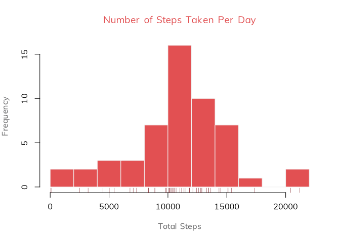

```r
# Histogram of Total Steps Per Day
par(family = "Font Awesome 5 Free", font = 1, col.main = "#EA6864", col.lab = "#777778")
hist(totalSteps$TotalSteps,
     breaks = 10,
     col = "#EA6864",
     border = "whitesmoke",
     main = "Number of Steps Taken Per Day",
     xlab = "Total Steps")
rug(totalSteps$TotalSteps, col = "firebrick4")
```

### Mean/Median Total Steps Per Day

```r
# Buliding Data frame
mean.med.tbl <- data.frame(c("Mean", "Median"), c(mean(totalSteps$TotalSteps), median((totalSteps$TotalSteps))))
# Table Output using kableExtra
kable(mean.med.tbl, align = c("l", "l"), col.names = c("Total Steps Per Day", "")) %>%
  kable_styling(bootstrap_options = "condensed", full_width = FALSE) %>%
  row_spec(row = 0, background = "#EA6864", color = "white", hline_after = TRUE)
```

| Total Steps Per Day |  |
| --- | --- |
| Mean | 10766.19 |
| Median | 10765.00 |

## 3. What is the average daily activity pattern?

In this section, the following tabs focus on:

1. A time series plot of the 5-minute interval (x-axis) and the average number of steps taken, averaged across all days (y-axis).
2. Identifying which 5-minute interval, on average across all the days in the data set, contains the maximum number of steps.

### Time Series Plot

Below shows a Time Series Plot between the 5-minute intervals and the average number of steps taken across all days.

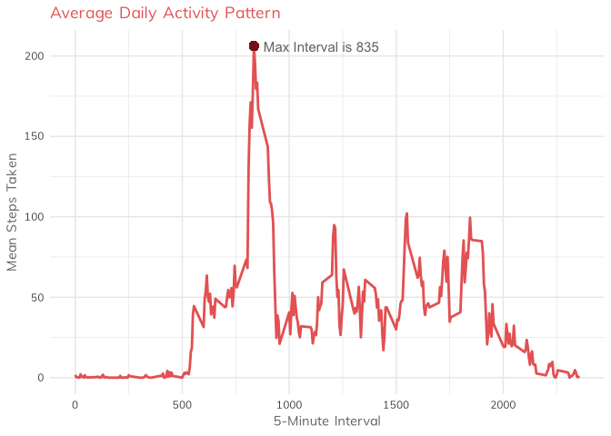

```r
# Find the Mean accross intervals
avgSteps <- activity %>%
  group_by(interval) %>%
  summarize(AvgDailyInterval = round(mean(steps, na.rm = TRUE), 2))

# Construct Plot
ggplot(avgSteps, aes(x = interval, y = AvgDailyInterval)) +
  geom_line(color = "#EA6864", size = 1) +
  theme_minimal(base_family = "Font Awesome 5 Free") +
  theme(axis.title = element_text(color = "#777778"),
        plot.title = element_text(color = "#EA6864", face = "bold")) +
  labs(title = "Average Daily Activity Pattern") +
  xlab("5-Minute Interval") +
  ylab("Mean Steps Taken") +
  geom_point(x = 835, y = 206.1698, inherit.aes = TRUE, color = "firebrick4", size = 3) +
  annotate("text", x = 1150, y = 206.1698, label = "Max Interval is 835", color = "#777778", size = 4)
```

### Max 5-Min Interval

The time series plot shows a spike of over 200+ steps. The following calculation and table below shows the details of the specific 5-minute interval spike:

```
max.interval <- avgSteps[which.max(avgSteps$AvgDailyInterval),]
```

```r
# Calculate Max Interval with which.max()
max.interval <- avgSteps[which.max(avgSteps$AvgDailyInterval),]
# Output table
kable(max.interval, col.names = c("Max Interval", "Average Steps"), align = "c") %>%
  kable_styling(bootstrap_options = "condensed", full_width = FALSE) %>%
  row_spec(row = 0, background = "#EA6864", color = "white")
```

| Max Interval | Average Steps |
| --- | --- |
| 835 | 206.17 |

## 4. Imputing missing values

Note that there are a number of days/intervals where there are missing values (coded as NA). The presence of missing days may introduce bias into some calculations or summaries of the data. The following tabs will:

1. Calculate and report the total number of missing values in the data set (i.e. the total number of rows with NAs).
2. Devise a strategy for filling in all of the missing values in the data set. The strategy formulated will use the mean for each 5-minute interval.
3. Create a new data set that is equal to the original data set but with the missing data filled in.
4. Make a histogram of the total number of steps taken each day and report the mean and median total number of steps taken per day.

### Missing Rows

```r
# Using complete cases() to find all missing rows
activity.comp <- activity[complete.cases(activity),]
# Subtracting original data frame rows from complete cases data frame rows to get total number of missing NA rows
missing.rows <- nrow(activity) - nrow(activity.comp)
```

The following will calculate the total number rows with missing values (coded as NA):

```
activity.comp <- activity[complete.cases(activity),]
missing.rows <- nrow(activity) - nrow(activity.comp)
```

There are a total of **2304** missing rows with NA in the original data set.

### Impute NAs

```r
activity.impute <- activity
activity.impute$steps[is.na(activity.impute$steps)] <- avgSteps$AvgDailyInterval[match(activity.impute$interval, avgSteps$interval)]
```

The NA values in the `steps` variable are replaced with the interval mean and stored into a new data frame `activity.impute`. The mean for each interval has already been calculated and stored in the data frame `avgSteps`. The following code will use the `match()` to match the mean interval value to the missing NAs in the `steps` column.

Below is the code:

```
activity.impute <- activity
activity.impute$steps[is.na(activity.impute$steps)] <- avgSteps$AvgDailyInterval[match(activity.impute$interval, avgSteps$interval)]
```

### Histogram: Imputed Values

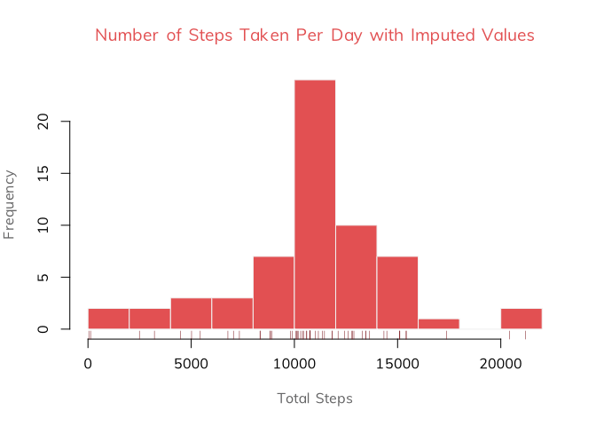

```r
# Calculating Total Number of Steps
imputeTotalSteps <- activity.impute %>%
  group_by(date) %>%
  summarize(TotalSteps = sum(steps), MeanSteps = mean(steps), MedianSteps = median(steps))

# Histogram of Total Steps Per Day
par(family = "Font Awesome 5 Free", font = 1, col.main = "#EA6864", col.lab = "#777778")
hist(imputeTotalSteps$TotalSteps,
     breaks = 10,
     col = "#EA6864",
     border = "whitesmoke",
     main = "Number of Steps Taken Per Day with Imputed Values",
     xlab = "Total Steps")
rug(imputeTotalSteps$TotalSteps, col = "firebrick4")
```

### Imputed Mean/Median

When imputing the *mean* of the 5-minute intervals, there is no difference of the mean between the original data frame and with the imputed data frame. The mean remains the same at **10,766** steps.

The *median* between the original and imputed data frames does change slightly going from **10,765** steps to **10,766**. Lastly, the total number of steps taken does increase quite significantly. Please see the table below:

```r
kable(data.frame(Value = c("Mean", "Median", "Total Steps"),
                 Org = c(mean(totalSteps$TotalSteps), median(totalSteps$TotalSteps), sum(totalSteps$TotalSteps)),
                 Impute = c(mean(imputeTotalSteps$TotalSteps), median(imputeTotalSteps$TotalSteps),
                            sum(imputeTotalSteps$TotalSteps))),
      col.names = c("", "Original Data Set", "Imputed Data Set"), align = c("l", "c", "c")) %>%
  kable_styling(bootstrap_options = "condensed", full_width = FALSE) %>%
  row_spec(row = 0, background = "#EA6864", color = "white")
```

|  | Original Data Set | Imputed Data Set |
| --- | --- | --- |
| Mean | 10766.19 | 10766.18 |
| Median | 10765.00 | 10766.13 |
| Total Steps | 570608.00 | 656737.04 |

## 5. Are there differences in activity patterns between weekdays and weekends?

For this part the weekdays function – weekdays() – may be of some help here. This function will be used with the imputed data set. The tabs will show:

1. A new factor variable in the data set with two levels – **“weekday”** and **“weekend”** indicating whether a given date is a weekday or weekend day.
2. A panel plot containing a time series plot of the 5-minute interval (x-axis) and the average number of steps taken, averaged across all weekday days or weekend days (y-axis).

### Factor Variable

```r
weekdays <- activity.impute %>%
  mutate(Weekday = weekdays(date)) %>%
  mutate(Weekday = factor(Weekday, levels = unique(Weekday),
                           labels = c("Weekday", "Weekday", "Weekday", "Weekday", "Weekday", "Weekend", "Weekend")))
```

The following code will create a new data frame `weekdays` using the `activity.impute` data frame and create new column `Weekday` with factor levels and labels titled weekday if the `date` falls on a Monday-Friday and weekend if the date falls on a Saturday or Sunday.

Below is the code:

```
weekdays <- activity.impute %>%
  mutate(Weekday = weekdays(date)) %>%
  mutate(Weekday = factor(Weekday, levels = unique(Weekday),
                           labels = c("Weekday", "Weekday", "Weekday", "Weekday", "Weekday", "Weekend", "Weekend")))
```

### Panel Time Series

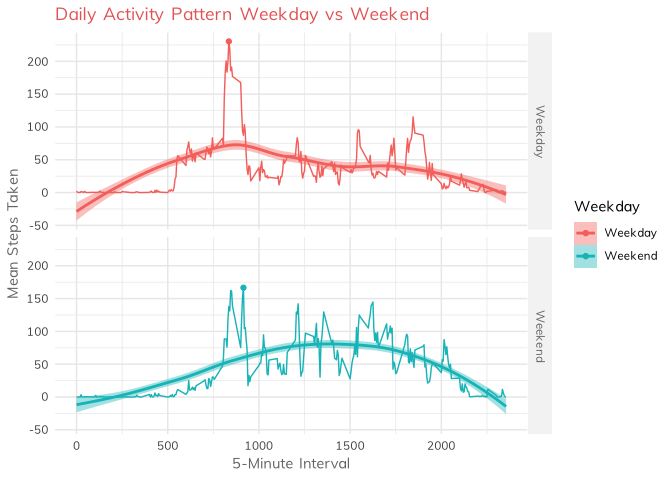

```r
# Filter Data Set
weekdaysGroup <- weekdays %>%
  group_by(interval, Weekday) %>%
  summarise(MeanSteps = mean(steps))

weekend <- weekdaysGroup %>%
  filter(Weekday == "Weekend")
weekend <- weekend[which.max(weekend$MeanSteps),]

weekday <- weekdaysGroup %>%
  filter(Weekday == "Weekday")
weekday <- weekday[which.max(weekday$MeanSteps),]

ggplot(weekdaysGroup, aes(interval, MeanSteps, color = Weekday, fill = Weekday)) +
  facet_grid(Weekday ~., ) +
  geom_line() +
  geom_smooth(method = "loess") +
  theme_minimal(base_family = "Font Awesome 5 Free") +
  theme(axis.title = element_text(color = "#777778"),
        plot.title = element_text(color = "#EA6864", face = "bold")) +
  labs(title = "Daily Activity Pattern Weekday vs Weekend") +
  xlab("5-Minute Interval") +
  ylab("Mean Steps Taken") +
  theme(strip.background = element_rect(fill = "whitesmoke", color = FALSE),
        strip.text = element_text(color = "#777778")) +
  geom_point(data = weekend, aes(x = interval, y = MeanSteps)) +
  geom_point(data = weekday, aes(x = interval, y = MeanSteps))
```

**Max Intervals of Weekday vs Weekend:**

```r
weekend <- weekdaysGroup %>%
  filter(Weekday == "Weekend")
weekend <- weekend[which.max(weekend$MeanSteps),]

weekday <- weekdaysGroup %>%
  filter(Weekday == "Weekday")
weekday <- weekday[which.max(weekday$MeanSteps),]

daytbl <- weekend
daytbl <- rbind(weekend, weekday)
daytbl <- daytbl %>%
  mutate(MeanSteps = round(MeanSteps, 0)) %>%
  select(Weekday, interval, MeanSteps)

kable(daytbl, col.names = c("", "Max Interval", "Mean Steps"), caption = "Max Interval Weekend vs Weekend") %>%
  kable_styling(bootstrap_options = "condensed", full_width = FALSE) %>%
  row_spec(0, background = "#EA6864", color = "white")
```

Max Interval Weekend vs Weekend

|  | Max Interval | Mean Steps |
| --- | --- | --- |
| Weekend | 915 | 167 |
| Weekday | 835 | 230 |